# Project Plan

Structural Health Monitoring (SHM)

Author

Thyge Vinther Ludvigsen, s203591

Published

24 Feb, 2026

# 1 Project Description

## 1.1 Background

**Tip**

Your PDR should begin with a section that sets the scene and that motivates the problem being studied. It describes some domain, and indicates a problem in general terms. Some questions you should be able to answer after reading the motivation section are:

1. What is the general area being addressed?
2. What is the motivation for studying a particular problem?
3. What makes it worth the effort?
4. Is it a ’real’ problem in everyday life?
5. Is it a ’theoretical’ problem that is worth solving?
6. Would anyone care if I solved this?

Structural Health Monitoring (SHM) is an emerging field concerned with extracting information about the condition, performance, and integrity of civil and mechanical structures. The information obtained through SHM is valuable for maintenance planning, risk assessment, and ensuring structural safety. As infrastructure systems age worldwide, there is an increasing need for reliable and cost effective monitoring strategies.

The construction and infrastructure sectors account for a significant portion of global greenhouse gas emissions. One way to reduce these emissions is to extend the service life of existing structures through timely maintenance and informed decision making. Effective monitoring allows interventions to be performed only when necessary, thereby avoiding premature replacement and reducing material consumption. In this context, SHM contributes not only to structural safety but also to sustainability.

Another strong motivation for SHM lies in the monitoring of critical infrastructure such as bridges, tunnels, and dams. Failures in such systems can have catastrophic societal and economic consequences. Traditional inspection methods are often manual, time consuming, and costly. In many cases, critical structural components are difficult to access, which increases inspection complexity and risk. SHM systems offer a continuous, automated, and potentially more cost efficient alternative for monitoring structural performance and reducing overall societal risk.

This project focuses on sensor placement for vibration based SHM. In vibration based methods, structural response data are used to extract modal properties such as natural frequencies, mode shapes, and damping ratios. These modal properties depend on the structure’s geometry, mass distribution, and stiffness, and changes in them may indicate structural damage. The accuracy of modal identification strongly depends on sensor placement. Poor sensor placement can result in insufficient or misleading information, making reliable damage detection difficult.

In practice, environmental effects such as temperature and humidity significantly influence measured vibration responses. These variations can mask or mimic damage related changes in modal properties, increasing the risk of false damage indications. Consequently, robust and well designed sensor placement strategies are essential to improve damage detectability and reduce uncertainty.

Although numerous studies in the literature have addressed optimal sensor placement for vibration based SHM, most approaches focus on mathematical or modal criteria (e.g., maximizing independence of mode shapes or information indices). Fewer studies consider the economic consequences of monitoring decisions, such as the costs associated with false positives, false negatives, and sensor installation.

The objective of this project is therefore to develop a Bayesian framework for optimal sensor placement in vibration based SHM that explicitly incorporates economic considerations. The goal is to determine sensor configurations that maximize expected economic value by balancing sensor costs, damage detection performance, and decision uncertainty. By integrating probabilistic modeling and decision theory, the project aims to contribute both theoretically and practically to the design of cost effective SHM systems.

## 1.2 Prior Work

**Tip**

You should provide a miniature literature review to give the reader enough background to understand the context of the research; a full review is usually deferred to the second Chapter of the final thesis.

It is, however, important that you as part of you PDR have identified some core literature references.

Some questions you should be able to answer in general terms after reading this section are:

- What is the research context and discipline that the thesis fits within?
- In general, who has looked at this area before?
- In general, what is the ‘state-of-art’ both in terms of methods?

## 1.3 Research Question

**Tip**

This section provides a very concise statement of your hypothesis / thesis / problems. The hypothesis or thesis is the highest-level problem or goal you are going to address. The specific list of problems usually a handful, although sub-problems are sometimes given — are things that need to be solved if you are going to satisfy your hypothesis/thesis. Problems should be stated unambiguously. The importance of the problem should be mentioned if it hasn’t already been done so in the prior sections. Of course, the problem must be worthy of a thesis. In general, there are a few typical types of research you can do:

- You can try to solve a real-world problem for some real-world users or organization.
- You can try to solve a ‘theoretical’ problem reported in the literature.
- You can try to replicate a scientific solution or method reported in the literature.
- You can develop a novel approach or method for solving a well-known problem

How can sensor placement in vibration based SHM be optimized using a Bayesian decision framework that accounts for uncertainty, damage detection performance, and economic consequences, and how does such a strategy perform when applied to a concrete frame building?

**Sub problems:**

1. How can a probabilistic model be formulated that links structural damage, vibration based modal properties, measurement uncertainty(, and environmental variability)?
2. How can false positive and false negative damage detections be quantified within a Bayesian inference framework?
3. How can economic consequences including sensor installation costs, inspection costs, and the costs of incorrect damage decisions be incorporated into a Bayes risk formulation?
4. How can the expected economic value of different sensor configurations be computed and compared?
5. How does the economically optimal sensor placement compare to traditional placement strategies when applied to a concrete frame building case study?

## 1.4 Research Goals and methods

**Tip**

While the above section details the problems, your job is to then translate those problems into research goals. Each goal should briefly indicate how you are going to solve the problem i.e., the method you will use to solve it. Note that some authors sometimes combine problem statements / goals / methods into a single section, while others separate it. Goals should be operational, i.e., if you later claim to achieve your goal, you should be able to match your solution against the goal statement. I cannot overstate how important it is to have clear goals. Most examiners highlight these goals, and after reading the thesis they then go back to see if you have actually accomplished your goals. If you have not, then you have a big problem in your thesis. Even worse are theses where problems and goals are not clearly stated, for it means people are trying to evaluate your solutions in a vacuum.

The overall goal of this thesis is to develop and evaluate a Bayesian decision theoretic framework for economically optimal sensor placement in vibration based SHM, demonstrated on a reinforced concrete frame building.

To achieve this, the following research goals are defined:

### 1.4.1 Goal 1: Develop Structural and Measurement Model

- Construct a finite element model of a reinforced concrete frame building.
- Define representative damage scenarios (e.g., stiffness reductions).
- Simulate modal properties (frequencies, mode shapes).
- Incorporate measurement noise “and environmental variability.”

**Method:** Numerical modeling and simulation.

### 1.4.2 Goal 2: Formulate Bayesian Damage Detection Framework

- Define prior distributions for structural parameters and damage states.
- Establish likelihood function based on vibration derived modal features.
- Implement Bayesian inference to estimate probability of damage.

**Method:** Probabilistic modeling and Bayesian inference.

### 1.4.3 Goal 3: Incorporate Economic Decision Model

- Define decision rule for damage detection.
- Quantify probabilities of false positives and false negatives.
- Assign economic costs to:
  - Sensor installation
  - Missed damage
  - False alarms
  - …
- Formulate expected loss (Bayes risk).

**Method:** Decision theoretic modeling.

### 1.4.4 Goal 4: Optimize Sensor Placement

- Define candidate sensor configurations.
- Evaluate configurations using expected economic loss.
- Identify placement minimizing Bayes risk.

**Method:** Optimization over discrete sensor layouts.

### 1.4.5 Goal 5: Case Study Evaluation

- Apply framework to the concrete frame model.
- Compare with traditional modal based placement methods.
- Perform sensitivity analysis on uncertainty and cost assumptions.

**Method:** Comparative numerical analysis.

## 1.5 Empirical Considerations

**Tip**

In this section you should outline the empirical – i.e., practical – setting of your project. You should address questions like:

- Where do you get your data? Where do you analyze it? Can you do this yourself?
- How are you going to build some technology?
- How do you get access to users?
- How do you get access to the needed resources, such as money, hardware, software, lab space, …?
- Who are you working with? A company, hospital, clinic, grass root organization,…
- What is your role? Are you expected to deliver something to an external partner?
- Are there any Intellectual Property Rights (IPR) issues involved?

# 2 Intended Learning Objectives

**Tip**

The intended learning objectives (ILO) of this Thesis are:

- can identify and reflect on technical scientific issues and understand the interaction between the various components that make up an issue
- can, on the basis of a clear academic profile, apply elements of current research at international level to develop ideas and solve problems
- masters technical scientific methodologies, theories and tools, and has the capacity to take a holistic view of and delimit a complex, open issue, see it in a broader academic and societal perspective and, on this basis, propose a variety of possible actions
- can, via analysis and modelling, develop relevant models, systems and processes for solving technological problems
- can communicate and mediate research-based knowledge both orally and in writing
- is familiar with and can seek out leading international research within his/her specialist area.
- can work independently and reflect on own learning, academic development and specialization
- masters technical problem-solving at a high level through project work, and has the capacity to work with and manage all phases of a project – including preparation of timetables, design, solution and documentation

# 3 Plan

## 3.1 Gantt Chart

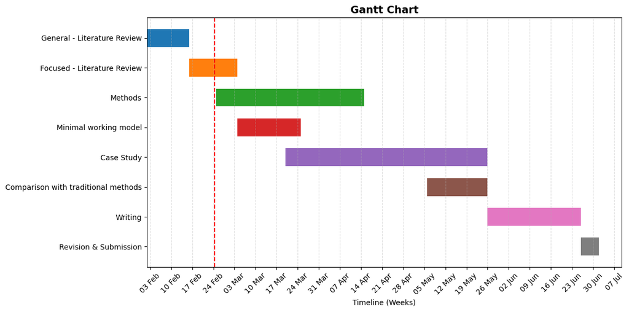

## 3.2 Activities

**Tip**

This section provides a table of the main phases and activities of the plan with a little description of each.

### 3.2.1 General Literature Review

This phase consists of a broad review of the structural health monitoring (SHM) field. The objective is to understand the fundamental concepts, common methodologies, and key challenges within SHM. Particular attention will be given to identifying current limitations and potential gaps in the literature that motivate the present study.

### 3.2.2 Focused Literature Review

This phase involves a more targeted review of research related to optimal sensor placement in SHM and decision theoretic approaches to monitoring system design. The goal is to understand existing optimization criteria, probabilistic frameworks, and economic formulations relevant to sensor placement.

### 3.2.3 Methods Development

In this phase, the methodological framework for the specific case study will be developed. This includes:

- Structural modeling of the system
- Damage modeling
- Measurement modeling
- Decision theoretic formulation
- Optimization strategy for sensor placement

The objective is to establish a complete computational framework for economically optimal sensor placement.

### 3.2.4 Minimal Working Model

A simplified version of the full framework will be implemented as an initial prototype. This minimal working model will allow testing and debugging of individual components before introducing additional complexity. It will serve as a foundation for validating the overall methodology.

### 3.2.5 Case Study

In this phase, the developed framework will be applied to a reinforced concrete frame building. The structural model, damage scenarios, measurement model, decision model, and optimization procedure will be integrated and evaluated in a realistic setting.

### 3.2.6 Comparison with Traditional Methods

The proposed approach will be compared with conventional sensor placement strategies, such as methods based on modal properties or information-theoretic indices. All approaches will be evaluated in terms of their expected economic value and decision performance.

### 3.2.7 Writing

During and after the modeling and case study phases, the thesis will be written and continuously refined. This includes documenting the methodology, presenting results, and developing clear illustrations and figures to support the analysis.

### 3.2.8 Revision and Submission

In the final phase, the thesis will be carefully reviewed to ensure clarity, consistency, and correctness. This includes proofreading, formatting adjustments, verification of references, and incorporation of supervisor feedback prior to submission.

## 3.3 Milestones

**Tip**

This section provides a table of the main milestones of the plan with a little description of each. Examples of milestones include:

1. Approvals (e.g., of a UX design, data management, or of a study involving patients);
2. Important deadlines (e.g., prototype ready for UX testing, recruitment of all patients, or final analysis of data done);
3. Acquisition of core resources (e.g., getting access to hardware, setting up a lab experiment, or getting access to test data);
4. Thesis milestones (e.g., the PDR, chapters, and final Thesis).

## 3.4 Deliverable

**Tip**

This section provides a table of the main deliverable of the plan with a little description of each. Examples of deliverable include: 1. Design products (e.g., UX design, a requirement analysis, a design model, a data model), 2. Hardware and Software (e.g., a UX prototype, a lab setup, an app for download in AppStore); 3. Data analysis (e.g., machine learning analysis or statistical analysis of user study data); 1. Thesis deliverable (e.g., chapters, figures).

## 3.5 Risk Analysis

**Tip**

A risk analysis identify the top-5 or so risks that can really upset the entire project. Typical risk factors are often those that are not under your own control. Examples include getting access to data from someone else, the ability to run some experiments that will generate data, getting access to hardware/software that is needed, and getting access to people, such as company representatives, users, and patients.